# RED WINE DATASET ANALYSIS by HUNG TUAN TRUONG

```
##
## 0.012 0.034 0.038 0.039 0.041 0.042 0.043 0.044 0.045 0.046 0.047 0.048
##     2     1     2     4     4     3     1     5     4     4     4     8
## 0.049  0.05 0.051 0.052 0.053 0.054 0.055 0.056 0.057 0.058 0.059  0.06
##     8    12     1    10     5    13     8     9    10    14    17    16
## 0.061 0.062 0.063 0.064 0.065 0.066 0.067 0.068 0.069  0.07 0.071 0.072
##    11    24    22    20    23    32    27    30    21    35    47    24
## 0.073 0.074 0.075 0.076 0.077 0.078 0.079  0.08 0.081 0.082 0.083 0.084
##    35    55    45    51    47    51    43    66    40    46    35    49
## 0.085 0.086 0.087 0.088 0.089  0.09 0.091 0.092 0.093 0.094 0.095 0.096
##    25    31    25    32    25    21    19    22    21    19    23    18
## 0.097 0.098 0.099   0.1 0.101 0.102 0.103 0.104 0.105 0.106 0.107 0.108
##    18    12     8    13     5    10     7    16     6     8     9     1
## 0.109  0.11 0.111 0.112 0.113 0.114 0.115 0.116 0.117 0.118 0.119  0.12
##     3     8     7     6     1    11     5     2     4     8     3     3
## 0.121 0.122 0.123 0.124 0.125 0.126 0.127 0.128 0.132 0.136 0.137 0.143
##     2     7     6     3     1     1     1     1     4     1     1     1
## 0.145 0.146 0.147 0.148 0.152 0.153 0.157 0.159 0.161 0.165 0.166 0.168
##     1     1     1     1     2     1     3     1     1     1     3     1
## 0.169  0.17 0.171 0.172 0.174 0.176 0.178 0.186  0.19 0.194   0.2 0.205
##     1     1     2     1     1     1     2     1     1     1     1     2
## 0.213 0.214 0.216 0.222 0.226  0.23 0.235 0.236 0.241 0.243  0.25 0.263
##     1     3     1     1     2     1     1     1     1     1     1     1
## 0.267  0.27 0.332 0.337 0.341 0.343 0.358  0.36 0.368 0.369 0.387 0.401
##     1     1     1     1     1     1     1     1     1     1     1     1
## 0.403 0.413 0.414 0.415 0.422 0.464 0.467  0.61 0.611
##     1     1     2     3     1     1     1     1     1
```

```
##    Min. 1st Qu.  Median    Mean 3rd Qu.    Max.
## 0.01200 0.07000 0.07900 0.08747 0.09000 0.61100
```

We can see that there’s almost a fixed range in the amount of chlorides contained in wine samples, from about 0.06 to slightly more than 0.1 g/dm^3. It is uncommon to see chlorides exceeding 0.114 g/dm^3, although there are two outliers at 0.61 g/dm^3. And unlike citric acid which we explored earlier, chlorides is an indispensable ingredient since its amount is more than zero in all wine samples in our dataset.

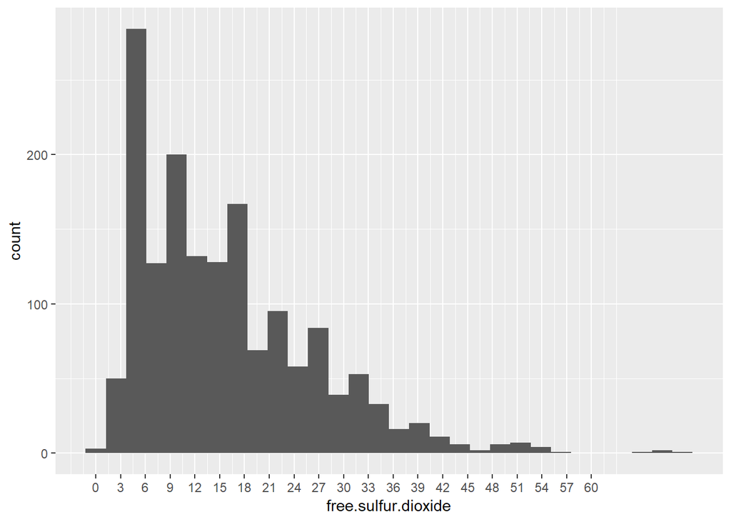

```
##    Min. 1st Qu.  Median    Mean 3rd Qu.    Max.
##    1.00    7.00   14.00   15.87   21.00   72.00
```

```
##
##    1    2    3    4    5  5.5    6    7    8    9   10   11   12   13   14
##    3    1   49   41  104    1  138   71   56   62   79   59   75   57   50
##   15   16   17   18   19   20   21   22   23   24   25   26   27   28   29
##   78   61   60   46   39   30   41   22   32   34   24   32   29   23   23
##   30   31   32   33   34   35   36   37 37.5   38   39   40 40.5   41   42
##   16   20   22   11   18   15   11    3    2    9    5    6    1    7    3
##   43   45   46   47   48   50   51   52   53   54   55   57   66   68   72
##    3    3    1    1    4    2    4    3    1    1    2    1    1    2    1
```

THe distribution of free sulfur dioxide amount appears to be right-skewed. It peaks at 6 mg/dm^3 and then goes downward from there. The amount of free sulfur dioxide ranges from 1 to 72 mg/dm^3 in our dataset, with the mean and median amount being 15.87 and 14 mg/dm^3 respectively.

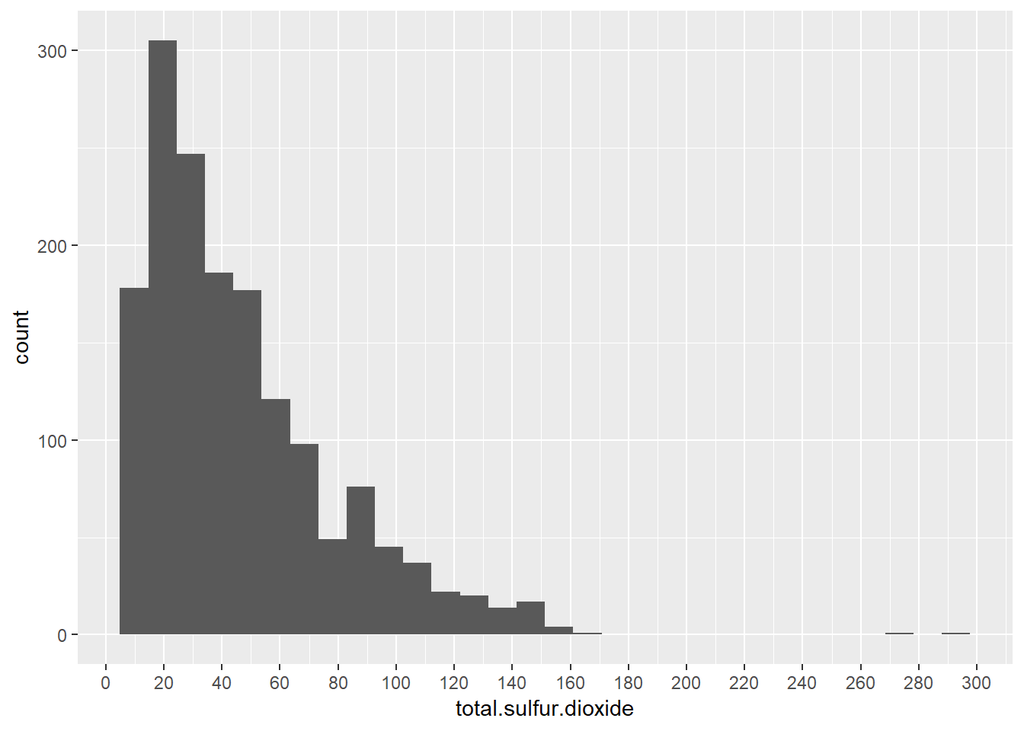

```
##    Min. 1st Qu.  Median    Mean 3rd Qu.    Max.
##    6.00   22.00   38.00   46.47   62.00  289.00
```

```
##
##    6    7    8    9   10   11   12   13   14   15   16   17   18   19   20
##    3    4   14   14   27   26   29   28   33   35   26   27   35   29   33
##   21   22   23   24   25   26   27   28   29   30   31   32   33   34   35
##   25   25   34   36   27   24   30   43   20   14   32   20   17   20   26
##   36   37   38   39   40   41   42   43   44   45   46   47   48   49   50
##   12   26   31   16   17   14   26   18   23   20   17   24   21   21   11
##   51   52   53   54   55   56   57   58   59   60   61   62   63   64   65
##   11   15   14   20   13   10    6   14    9   18    9    9   13   10   17
##   66   67   68   69   70   71   72   73   74   75   76   77 77.5   78   79
##    9   12   10    8    8    7   10    7    8    5    3    8    2    4    5
##   80   81   82   83   84   85   86   87   88   89   90   91   92   93   94
##    4    6    4    2    6    9   10    6   14    9    5    7    8    2    8
##   95   96   98   99  100  101  102  103  104  105  106  108  109  110  111
##    4    5    7    6    3    4    6    2    5    5    6    3    4    6    3
##  112  113  114  115  116  119  120  121  122  124  125  126  127  128  129
##    3    4    2    2    1    7    2    4    3    3    2    1    2    2    3
##  130  131  133  134  135  136  139  140  141  142  143  144  145  147  148
##    1    3    3    2    2    2    1    1    3    1    2    3    3    3    2
##  149  151  152  153  155  160  165  278  289
##    1    2    1    1    1    1    1    1    1
```

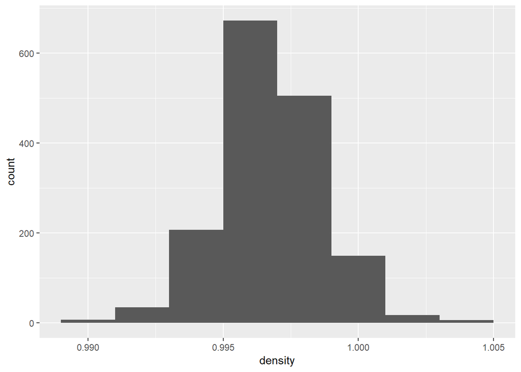

```
##    Min. 1st Qu.  Median    Mean 3rd Qu.    Max.
##  0.9901  0.9956  0.9968  0.9967  0.9978  1.0037
```

There does not seem to be much variance in the density of water in all wine samples in the dataset.All density values are very close to 1 g/cm^3.

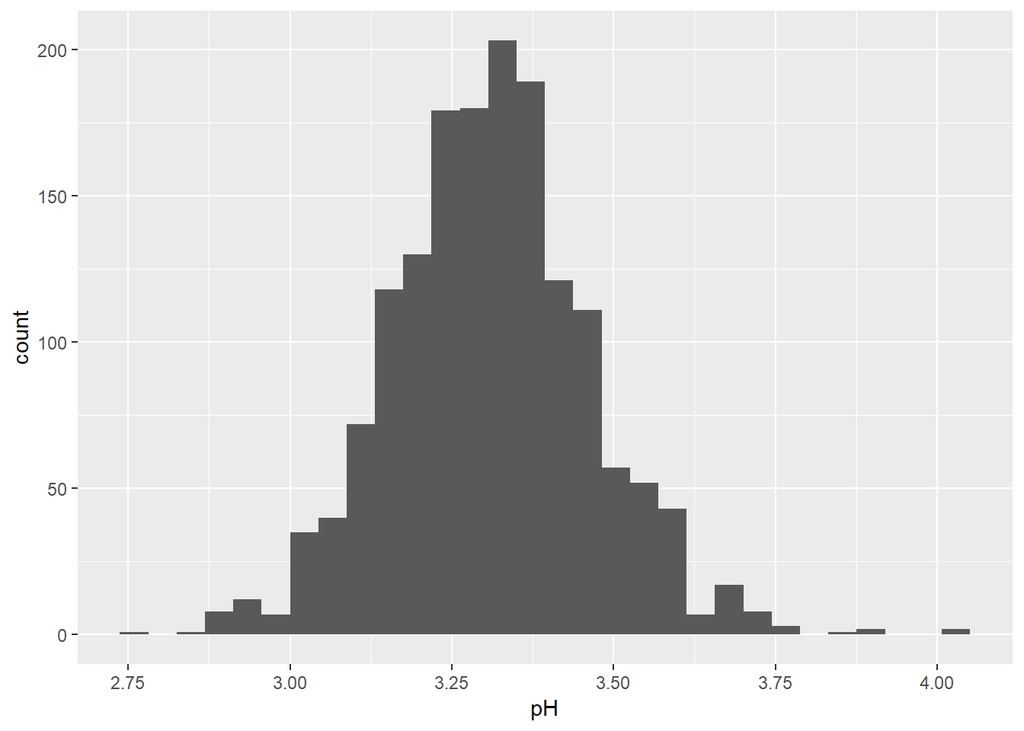

```
##    Min. 1st Qu.  Median    Mean 3rd Qu.    Max.
##   2.740   3.210   3.310   3.311   3.400   4.010
```

The histogram for pH values of all wine samples in our dataset represents a normal distribution. As such, the median and mean pH value are almost equal to one another, being 3.310 and 3.311 respectively.

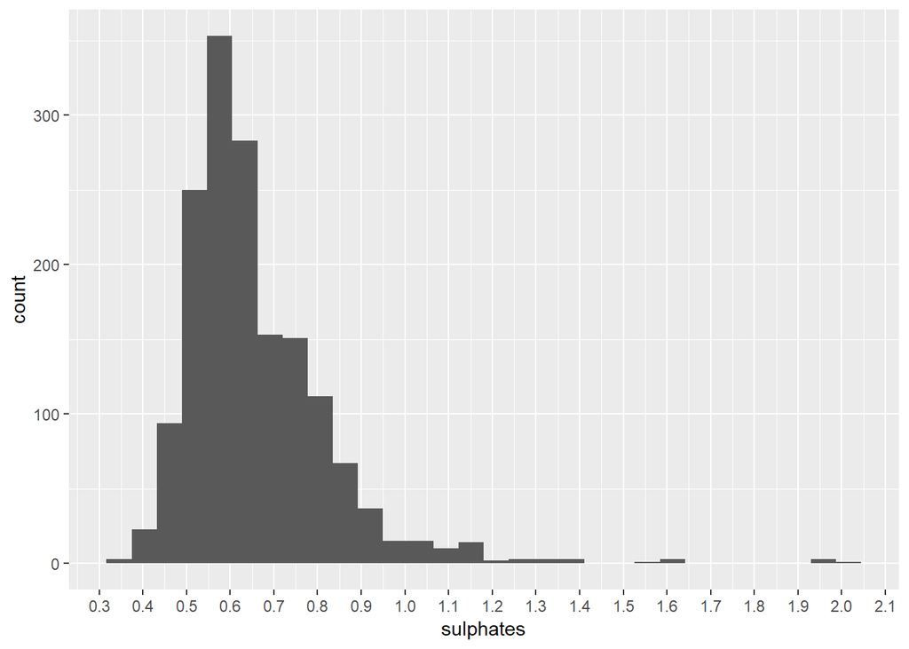

```
##
## 0.33 0.37 0.39  0.4 0.42 0.43 0.44 0.45 0.46 0.47 0.48 0.49  0.5 0.51 0.52
##    1    2    6    4    5    8   16   12   18   19   29   31   27   26   47
## 0.53 0.54 0.55 0.56 0.57 0.58 0.59  0.6 0.61 0.62 0.63 0.64 0.65 0.66 0.67
##   51   68   50   60   55   68   51   69   45   61   48   46   41   42   36
## 0.68 0.69  0.7 0.71 0.72 0.73 0.74 0.75 0.76 0.77 0.78 0.79  0.8 0.81 0.82
##   35   23   33   26   28   26   26   20   25   26   23   18   19   15   22
## 0.83 0.84 0.85 0.86 0.87 0.88 0.89  0.9 0.91 0.92 0.93 0.94 0.95 0.96 0.97
##   15   13   14   13   13    7    7    8    8    5   10    4    2    3    6
## 0.98 0.99    1 1.01 1.02 1.03 1.04 1.05 1.06 1.07 1.08 1.09  1.1 1.11 1.12
##    2    3    1    1    3    2    2    3    4    2    3    1    2    1    1
## 1.13 1.14 1.15 1.16 1.17 1.18  1.2 1.22 1.26 1.28 1.31 1.33 1.34 1.36 1.56
##    2    2    1    1    5    3    1    1    1    2    1    1    1    3    1
## 1.59 1.61 1.62 1.95 1.98    2
##    1    1    1    2    1    1
```

```
##    Min. 1st Qu.  Median    Mean 3rd Qu.    Max.
##  0.3300  0.5500  0.6200  0.6581  0.7300  2.0000
```

Again, we can see that the histogram for sulphates is also positively-skewed.The mode is at 0.6 g/dm^3 while median amount is 0.62 g/dm^3 and mean amount is 0.6581 g/dm^3. There are many outliers, including one at 2 g/dm^3 at seen from the histogram.

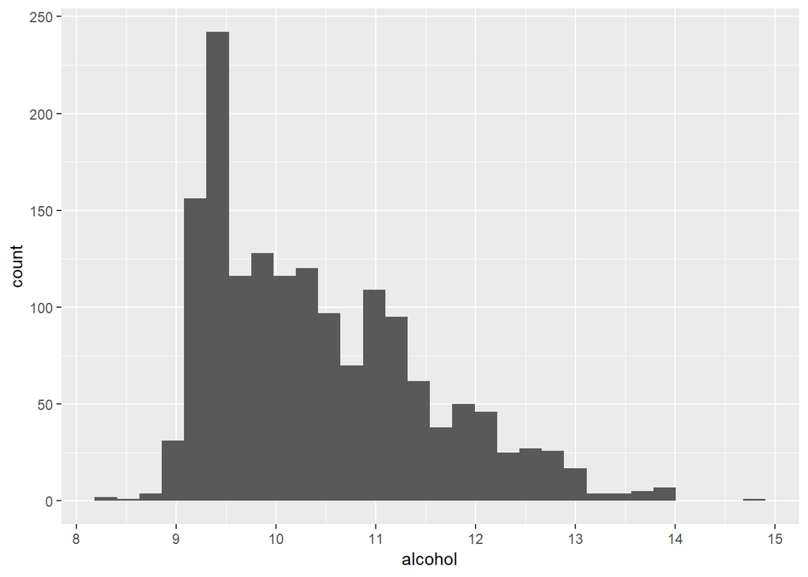

```
##    Min. 1st Qu.  Median    Mean 3rd Qu.    Max.
##    8.40    9.50   10.20   10.42   11.10   14.90
```

We can clearly see that the distribution for alcohol amounts as shown in the above histogram is skewed to the right. The mean value at 10.42 % is slightly higher than the median one at 10.20 %. There’s a noticable outlier at 14.90 %, while most wines contain an alcohol percentage from 9 % to 14 %.

# Univariate Analysis

### What is the structure of your dataset?

The dataset contains 1599 red wines with the following 12 attributes: - fixed acidity. - volatile acidity. - citric acid. - residual sugar. - chlorides. - free sulfur dioxide. - total sulfur dioxide. - density. - pH. - sulphates. - alcohol. - quality.

Quality is a discrete quantitative variable ( 0 is the lowest and 10 is the highest ), while all other variables as listed above are continuous quantitative.

Some obversations:

- Most red wines receive the quality score of either 5 or 6, with the lowest and highest score in the dataset being 3 and 8 respectively.
- Residual sugar, fixed acidity, chlorides, total sulfur dioxide and sulphates data are skewed to the right.
- pH values in the dataset are normally distributed, with the vast majority being between 2.8 and 3.75.
- All density values are very close to exactly 1.
- Most alcohol contents are from 8.4 to 14 percent.
- Not all wines contain citric acid.

### What is/are the main feature(s) of interest in your dataset?

The main features in this dataset are quality and alcohol.

We shall be investigating further to see if there is any correlation between alcohol and the quality rating of red wine.

### What other features in the dataset do you think will help support your investigation into your feature(s) of interest?

Volatile acidity, sulphates are some of the other variables that we will pay particular attention to in our analysis to see whether they also influence the quality of wine and if so, to what extent.

# Bivariate Plots Section

```
##                                 X fixed.acidity volatile.acidity
## X                     1.000000000   -0.26848392     -0.008815099
## fixed.acidity        -0.268483920    1.00000000     -0.256130895
## volatile.acidity     -0.008815099   -0.25613089      1.000000000
## citric.acid          -0.153551355    0.67170343     -0.552495685
## residual.sugar       -0.031260835    0.11477672      0.001917882
## chlorides            -0.119868519    0.09370519      0.061297772
## free.sulfur.dioxide   0.090479643   -0.15379419     -0.010503827
## total.sulfur.dioxide -0.117849669   -0.11318144      0.076470005
## density              -0.368372087    0.66804729      0.022026232
## pH                    0.136005328   -0.68297819      0.234937294
## sulphates            -0.125306999    0.18300566     -0.260986685
## alcohol               0.245122841   -0.06166827     -0.202288027
## quality               0.066452608    0.12405165     -0.390557780
##                      citric.acid residual.sugar    chlorides
## X                    -0.15355136   -0.031260835 -0.119868519
## fixed.acidity         0.67170343    0.114776724  0.093705186
## volatile.acidity     -0.55249568    0.001917882  0.061297772
## citric.acid           1.00000000    0.143577162  0.203822914
## residual.sugar        0.14357716    1.000000000  0.055609535
## chlorides             0.20382291    0.055609535  1.000000000
## free.sulfur.dioxide  -0.06097813    0.187048995  0.005562147
## total.sulfur.dioxide  0.03553302    0.203027882  0.047400468
## density               0.36494718    0.355283371  0.200632327
## pH                   -0.54190414   -0.085652422 -0.265026131
## sulphates             0.31277004    0.005527121  0.371260481
## alcohol               0.10990325    0.042075437 -0.221140545
## quality               0.22637251    0.013731637 -0.128906560
##                      free.sulfur.dioxide total.sulfur.dioxide     density
## X                            0.090479643          -0.11784967 -0.36837209
## fixed.acidity               -0.153794193          -0.11318144  0.66804729
## volatile.acidity            -0.010503827           0.07647000  0.02202623
## citric.acid                 -0.060978129           0.03553302  0.36494718
## residual.sugar               0.187048995           0.20302788  0.35528337
## chlorides                    0.005562147           0.04740047  0.20063233
## free.sulfur.dioxide          1.000000000           0.66766645 -0.02194583
## total.sulfur.dioxide         0.667666450           1.00000000  0.07126948
## density                     -0.021945831           0.07126948  1.00000000
## pH                           0.070377499          -0.06649456 -0.34169933
## sulphates                    0.051657572           0.04294684  0.14850641
## alcohol                     -0.069408354          -0.20565394 -0.49617977
## quality                     -0.050656057          -0.18510029 -0.17491923
##                               pH    sulphates     alcohol     quality
## X                     0.13600533 -0.125306999  0.24512284  0.06645261
## fixed.acidity        -0.68297819  0.183005664 -0.06166827  0.12405165
## volatile.acidity      0.23493729 -0.260986685 -0.20228803 -0.39055778
## citric.acid          -0.54190414  0.312770044  0.10990325  0.22637251
## residual.sugar       -0.08565242  0.005527121  0.04207544  0.01373164
## chlorides            -0.26502613  0.371260481 -0.22114054 -0.12890656
## free.sulfur.dioxide   0.07037750  0.051657572 -0.06940835 -0.05065606
## total.sulfur.dioxide -0.06649456  0.042946836 -0.20565394 -0.18510029
## density              -0.34169933  0.148506412 -0.49617977 -0.17491923
## pH                    1.00000000 -0.196647602  0.20563251 -0.05773139
## sulphates            -0.19664760  1.000000000  0.09359475  0.25139708
## alcohol               0.20563251  0.093594750  1.00000000  0.47616632
## quality              -0.05773139  0.251397079  0.47616632  1.00000000
```

Here we can see there’s a moderate positive correlation between quality rating and alcohol. A moderate negative correlation between quality and volatile acidity amount is also easily noted.

Other noteworthy relations include:

- citric acid and fixed acidity.
- density and fixed acidity.
- pH and fixed acidity.
- citric acid and volatile acidity.
- citric acid and pH.
- free sulfur dioxide and total sulfur dioxide.
- alcohol and density.

We will explore all these relations as we go further into this section. But first, Let’s create scatterplot matrices of all variables in our dataset:

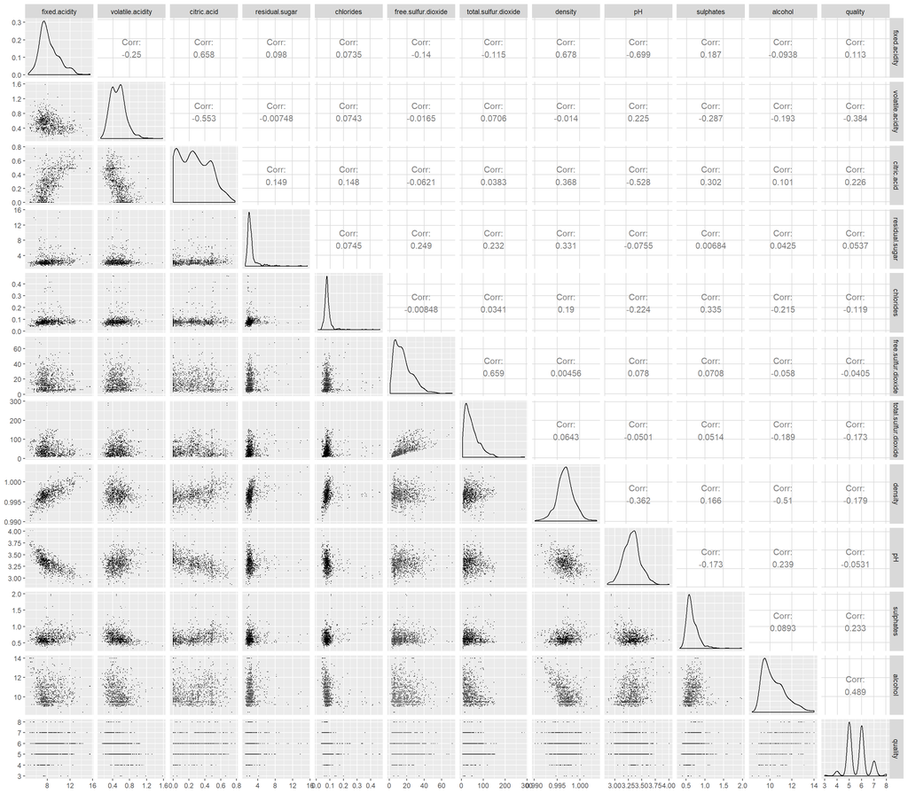

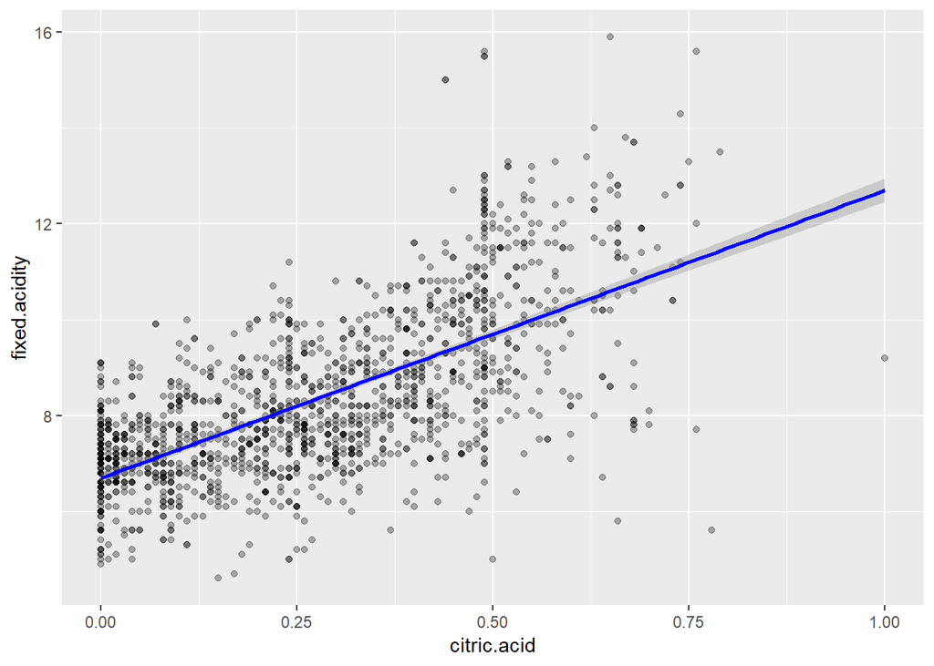

```
##
##  Pearson's product-moment correlation
##
## data:  wine_data$citric.acid and wine_data$fixed.acidity
## t = 36.234, df = 1597, p-value < 2.2e-16
## alternative hypothesis: true correlation is not equal to 0
## 95 percent confidence interval:
##  0.6438839 0.6977493
## sample estimates:
##       cor
## 0.6717034
```

We can see that there’s a pretty strong positive correlation of 0.6717 between fixed acidity and citric acid amount in our wine dataset.

This makes sense since citric acid is a fixed acidity itself, and if citric acid increases/decreases by a certain amount, that same fluctuation should also apply to fixed acidity.

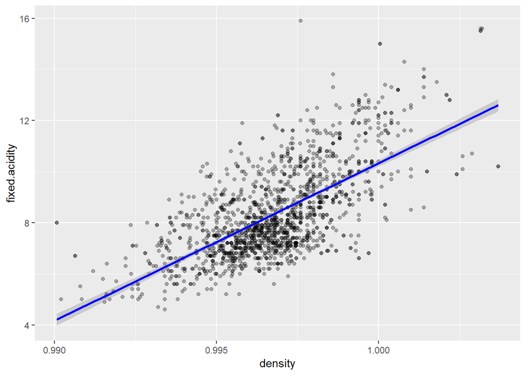

```
##
##  Pearson's product-moment correlation
##
## data:  wine_data$density and wine_data$fixed.acidity
## t = 35.877, df = 1597, p-value < 2.2e-16
## alternative hypothesis: true correlation is not equal to 0
## 95 percent confidence interval:
##  0.6399847 0.6943302
## sample estimates:
##       cor
## 0.6680473
```

Here we can see another strong positive correlation at 0.668 between fixed acidity amount and density of red wine samples in the dataset.

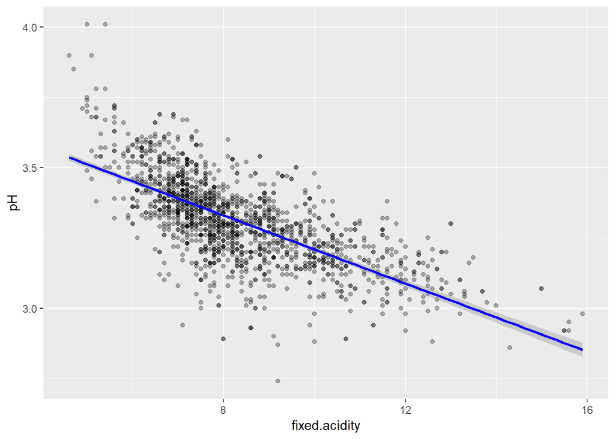

```
##
##  Pearson's product-moment correlation
##
## data:  wine_data$pH and wine_data$fixed.acidity
## t = -37.366, df = 1597, p-value < 2.2e-16
## alternative hypothesis: true correlation is not equal to 0
## 95 percent confidence interval:
##  -0.7082857 -0.6559174
## sample estimates:
##        cor
## -0.6829782
```

Contrary to the above, the relationship between fixed acidity and pH appears to be negatively correlated at -0.6830.

Looking back at the description of pH, we know that the more acidic a wine is, the lower pH score it will receive.

So our finding just reinforces our intuition that there should be a negative correlation between these 2 variables.

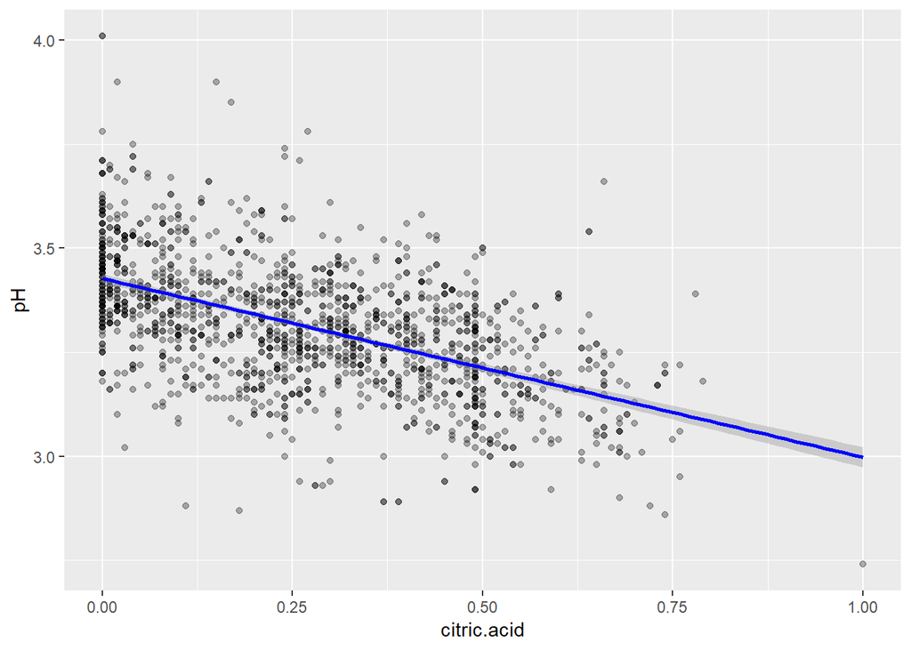

```
##
##  Pearson's product-moment correlation
##
## data:  wine_data$pH and wine_data$citric.acid
## t = -25.767, df = 1597, p-value < 2.2e-16
## alternative hypothesis: true correlation is not equal to 0
## 95 percent confidence interval:
##  -0.5756337 -0.5063336
## sample estimates:
##        cor
## -0.5419041
```

Again it appears that pH and citric acid is moderately negatively-correlated to one another.

We can use the same clarification with fixed acidity earlier to explain for this phenomenon.

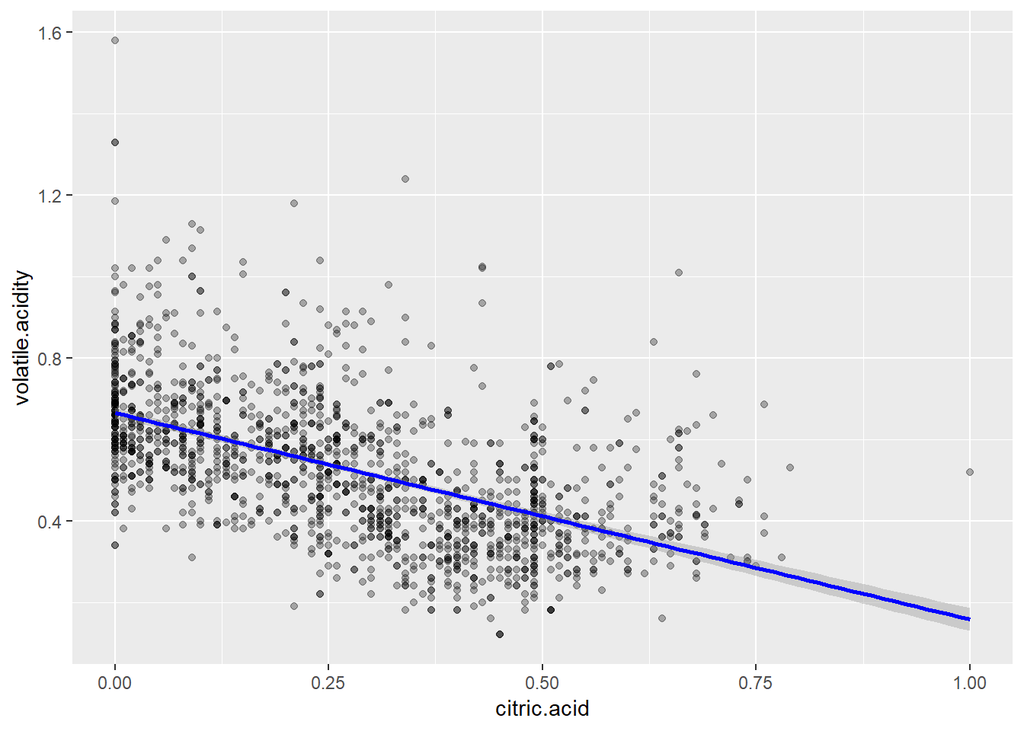

```
##
##  Pearson's product-moment correlation
##
## data:  wine_data$volatile.acidity and wine_data$citric.acid
## t = -26.489, df = 1597, p-value < 2.2e-16
## alternative hypothesis: true correlation is not equal to 0
## 95 percent confidence interval:
##  -0.5856550 -0.5174902
## sample estimates:
##        cor
## -0.5524957
```

There is a moderate negative correlation between citric acid and volatile acidity at -0.5525.

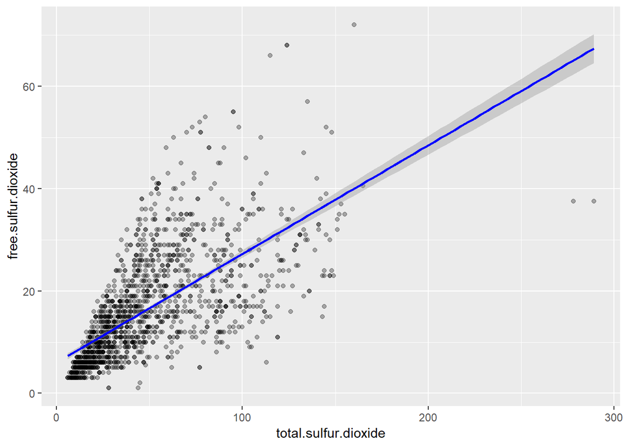

```
##
##  Pearson's product-moment correlation
##
## data:  wine_data$free.sulfur.dioxide and wine_data$total.sulfur.dioxide
## t = 35.84, df = 1597, p-value < 2.2e-16
## alternative hypothesis: true correlation is not equal to 0
## 95 percent confidence interval:
##  0.6395786 0.6939740
## sample estimates:
##       cor
## 0.6676665
```

Compared to the relation between citric acid and fixed acidity, we can see some similarities here as free sulfur dioxide is also part of the total sulfur dioxide amount.

Free sulfur dioxide is positively correlated with total sulfur dioxide at 0.6677, and their correlation also appears to be pretty strong.

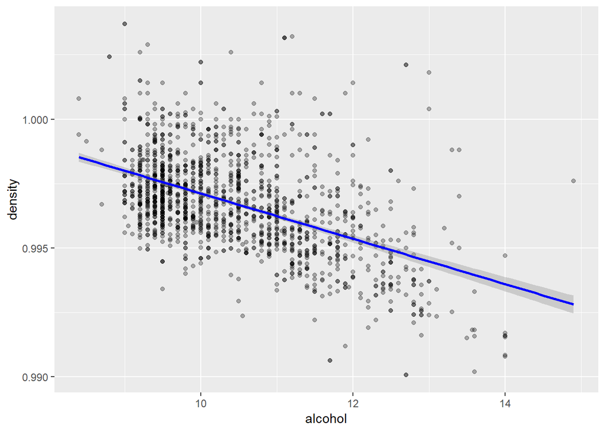

```
##
##  Pearson's product-moment correlation
##
## data:  wine_data$alcohol and wine_data$density
## t = -22.838, df = 1597, p-value < 2.2e-16
## alternative hypothesis: true correlation is not equal to 0
## 95 percent confidence interval:
##  -0.5322547 -0.4583061
## sample estimates:
##        cor
## -0.4961798
```

There is a moderate negative correlation between alcohol and wine density at -0.496.

As seen in the description of attributes, the density of water is dependent on the proportion of alcohol and sugar.

Since alcohol and water do not mix with one another, the more alcohol a wine sample contains, the lesser the proportion of water should be, which corresponds with the correlation value as shown above.

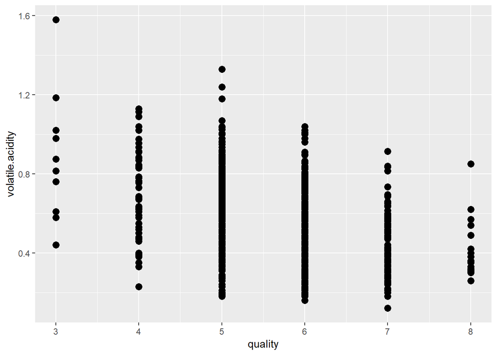

```
##
##  Pearson's product-moment correlation
##
## data:  wine_data$quality and wine_data$volatile.acidity
## t = -16.954, df = 1597, p-value < 2.2e-16
## alternative hypothesis: true correlation is not equal to 0
## 95 percent confidence interval:
##  -0.4313210 -0.3482032
## sample estimates:
##        cor
## -0.3905578
```

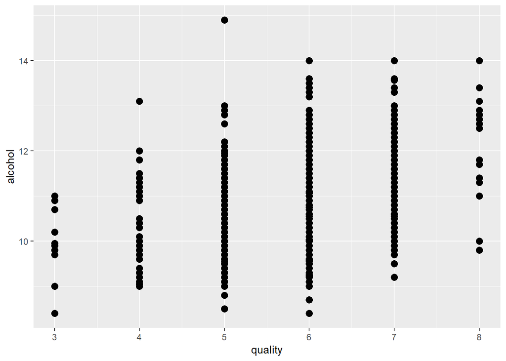

```
##
##  Pearson's product-moment correlation
##
## data:  wine_data$quality and wine_data$alcohol
## t = 21.639, df = 1597, p-value < 2.2e-16
## alternative hypothesis: true correlation is not equal to 0
## 95 percent confidence interval:
##  0.4373540 0.5132081
## sample estimates:
##       cor
## 0.4761663
```

As seen from above, we created two scatterplots that describe how quality of wine in the dataset correlates with volatile acidity and alcohol respectively.

It can still be inferred from the graphs that there is moderate negative correlation between volatile acidity and quality, as well as moderate positive correlation between alcohol and quality.

However, these plots do not seem to paint the whole picture as conclusive and in-depth and as I had originally hoped.

At this point, I decide to dig a little bit deeper into these relationships to see if there are still any hidden patterns yet to be found.

```
## wine_data$quality: 3
##    Min. 1st Qu.  Median    Mean 3rd Qu.    Max.
##   8.400   9.725   9.925   9.955  10.575  11.000
## --------------------------------------------------------
## wine_data$quality: 4
##    Min. 1st Qu.  Median    Mean 3rd Qu.    Max.
##    9.00    9.60   10.00   10.27   11.00   13.10
## --------------------------------------------------------
## wine_data$quality: 5
##    Min. 1st Qu.  Median    Mean 3rd Qu.    Max.
##     8.5     9.4     9.7     9.9    10.2    14.9
## --------------------------------------------------------
## wine_data$quality: 6
##    Min. 1st Qu.  Median    Mean 3rd Qu.    Max.
##    8.40    9.80   10.50   10.63   11.30   14.00
## --------------------------------------------------------
## wine_data$quality: 7
##    Min. 1st Qu.  Median    Mean 3rd Qu.    Max.
##    9.20   10.80   11.50   11.47   12.10   14.00
## --------------------------------------------------------
## wine_data$quality: 8
##    Min. 1st Qu.  Median    Mean 3rd Qu.    Max.
##    9.80   11.32   12.15   12.09   12.88   14.00
```

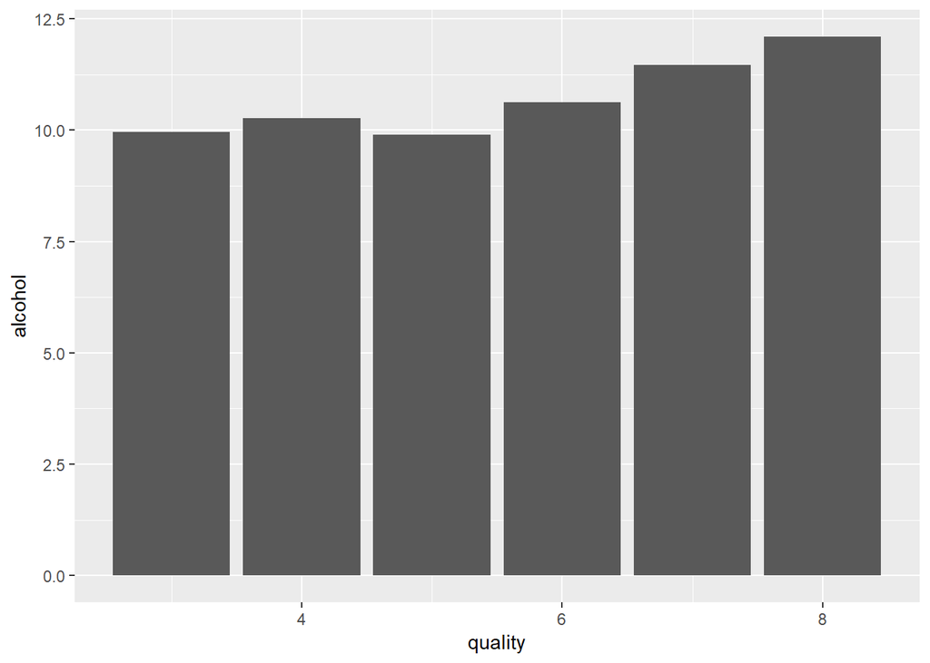

Let’s look at the data and bar chart illustrating the mean amount of alcohol by each quality rating.

It appears the overall trend is that as the mean amount of alcohol, the quality would also increase.

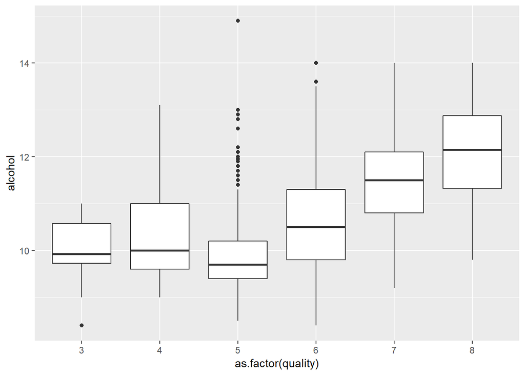

Here we also have a box plot for alcohol amount classified by quality rating.

We can easily see the overall trend for all quartiles is on the increase as quality improves, except for quality rating of 5 as they actually decreases.

There are many outlier values for quality rating of 5, partly because there are more wine samples with this rating compared to other quality scores.

```
## wine_data$quality: 3
##    Min. 1st Qu.  Median    Mean 3rd Qu.    Max.
##  0.4400  0.6475  0.8450  0.8845  1.0100  1.5800
## --------------------------------------------------------
## wine_data$quality: 4
##    Min. 1st Qu.  Median    Mean 3rd Qu.    Max.
##   0.230   0.530   0.670   0.694   0.870   1.130
## --------------------------------------------------------
## wine_data$quality: 5
##    Min. 1st Qu.  Median    Mean 3rd Qu.    Max.
##   0.180   0.460   0.580   0.577   0.670   1.330
## --------------------------------------------------------
## wine_data$quality: 6
##    Min. 1st Qu.  Median    Mean 3rd Qu.    Max.
##  0.1600  0.3800  0.4900  0.4975  0.6000  1.0400
## --------------------------------------------------------
## wine_data$quality: 7
##    Min. 1st Qu.  Median    Mean 3rd Qu.    Max.
##  0.1200  0.3000  0.3700  0.4039  0.4850  0.9150
## --------------------------------------------------------
## wine_data$quality: 8
##    Min. 1st Qu.  Median    Mean 3rd Qu.    Max.
##  0.2600  0.3350  0.3700  0.4233  0.4725  0.8500
```

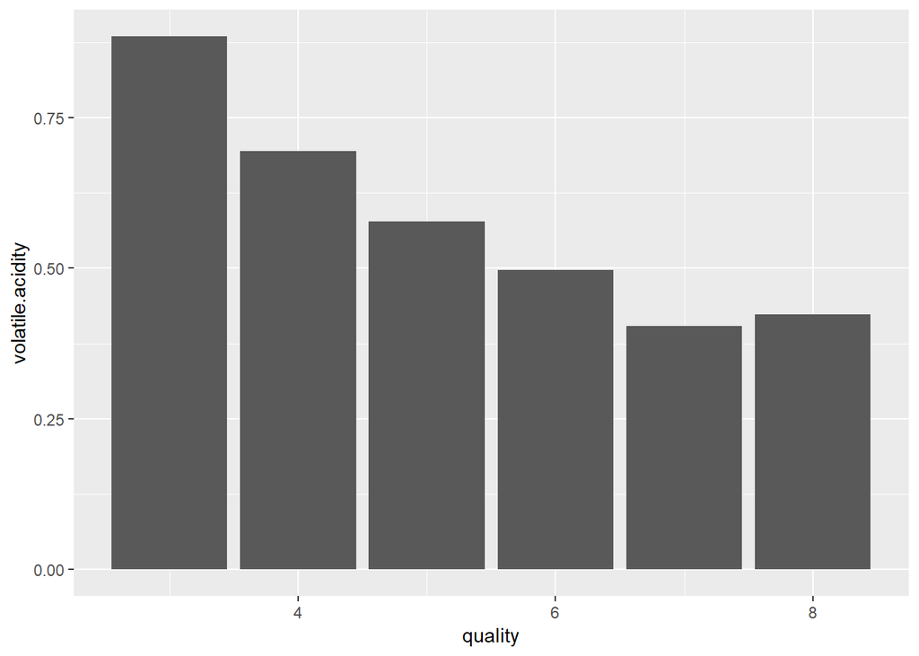

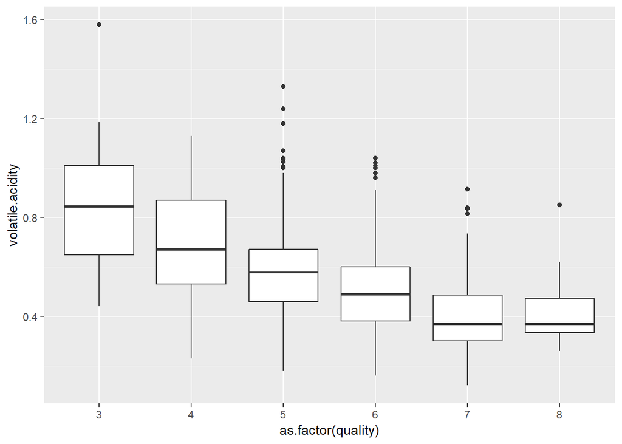

We can perform the same analysis as above with volatile acidity.

The mean amount of volatile acidity decreases as quality improves, with the sole exception of quality score of 8 when it slightly increases.

The same also applies to all quartiles of volatily acidity. More specifically, as quality rating goes up, the 1st, median and 3rd quartile all generally decreases.

```
## wine_data$quality: 3
##    Min. 1st Qu.  Median    Mean 3rd Qu.    Max.
##  0.4000  0.5125  0.5450  0.5700  0.6150  0.8600
## --------------------------------------------------------
## wine_data$quality: 4
##    Min. 1st Qu.  Median    Mean 3rd Qu.    Max.
##  0.3300  0.4900  0.5600  0.5964  0.6000  2.0000
## --------------------------------------------------------
## wine_data$quality: 5
##    Min. 1st Qu.  Median    Mean 3rd Qu.    Max.
##   0.370   0.530   0.580   0.621   0.660   1.980
## --------------------------------------------------------
## wine_data$quality: 6
##    Min. 1st Qu.  Median    Mean 3rd Qu.    Max.
##  0.4000  0.5800  0.6400  0.6753  0.7500  1.9500
## --------------------------------------------------------
## wine_data$quality: 7
##    Min. 1st Qu.  Median    Mean 3rd Qu.    Max.
##  0.3900  0.6500  0.7400  0.7413  0.8300  1.3600
## --------------------------------------------------------
## wine_data$quality: 8
##    Min. 1st Qu.  Median    Mean 3rd Qu.    Max.
##  0.6300  0.6900  0.7400  0.7678  0.8200  1.1000
```

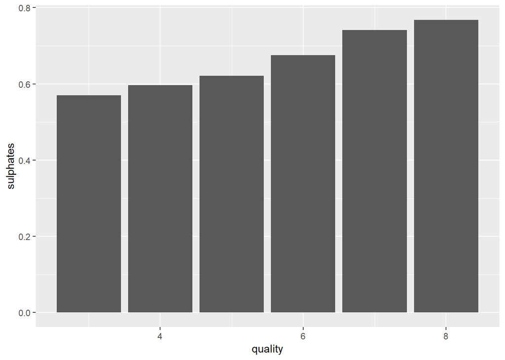

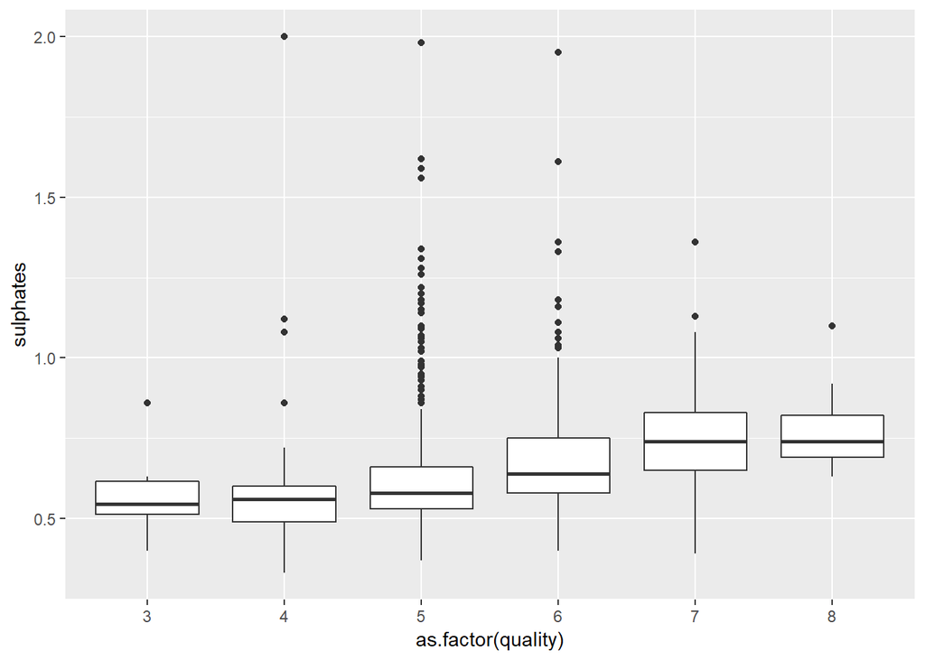

Here we will also take a look at sulphates amount by quality rating.

It appears that the average amount of sulphates will increase as quality score rises.

The same trend also applies with 1st, 2nd and 3rd quartile. They, as a whole, all go up when quality improves with only a few exception.

# Bivariate Analysis

### Talk about some of the relationships you observed in this part of the investigation. How did the feature(s) of interest vary with other features in the dataset?

We noticed that there is a moderate negative correlation between red wine’s volatile acidity and quality score.

A moderate positive correlation also exists between alcohol amount and a red wine’s quality score.

By continuing to explore further, we found out that with some minor exception, as quality score increases, the mean amount of alcohol and sulphates in wine samples of each score also increases. The reverse is true with volatile acidity, for its average value decreases as quality score improves.

The same trend can also be observed with all quartile values, including the median. To be more specific, for alcohol and sulphates, all quartiles values generally increases as quality rating goes up. Volatile acidity, on the other hand, displayed a downward trend as quality improves.

### Did you observe any interesting relationships between the other features (not the main feature(s) of interest)?

Beside the relationship between quality score and some noteworthy variables, we found out there exists some significant correlation between other features in our red wine dataset.

Citric acid and fixed acidity, density and fixed acidity, free sulfur dioxide and total sulfur dioxide, all these pairs of features show moderate positive correlation.

Fixed acidity and pH, on the other hand, display moderate negative correlation to each other. This moderate negative correlation is also true with citric acid and pH, citric acid and volatile acidity, alcohol and density as shown above in the plots.

### What was the strongest relationship you found?

The strongest relationships are those between citric and fixed acidity, density and fixed acidity, pH and fixed acidity, free sulfur dioxide and total sulfur dioxide, with correlation value being close to -0.7 or 0.7.

With that being said, none of the feature pairs in the red wine dataset could be said to strongly correlate with one another ( with strong correlation assumed to be equal or larger than 0.7, or, equal or lower than -0.7).

# Multivariate Plots Section

In this section, we are going to dive even deeper into the red wine dataset by examining the relationships between multiple features at the same time.

For example, previously we have studied the correlation between alcohol and density. Now, we are going to take a closer look at this relationship by adding another feature: quality score.

Besides, we will create density plots for a number of features by dividing them into subgroups based on their quality scores.

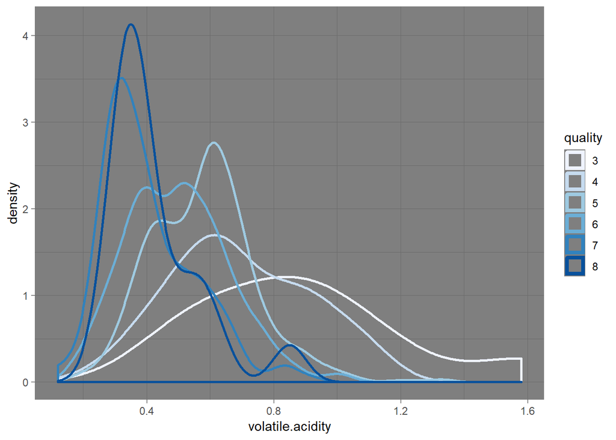

The above density plot of volatile acidity reveals that wines with higher quality score such as 6 or 8 tend to have lower volatile acidity amount, typically below 0.8 g/dm^3. Meanwhile, those with volatile acidity amount more than 0.8 g/dm^3 are much more likely to receive lower quality score of 3 or 4.

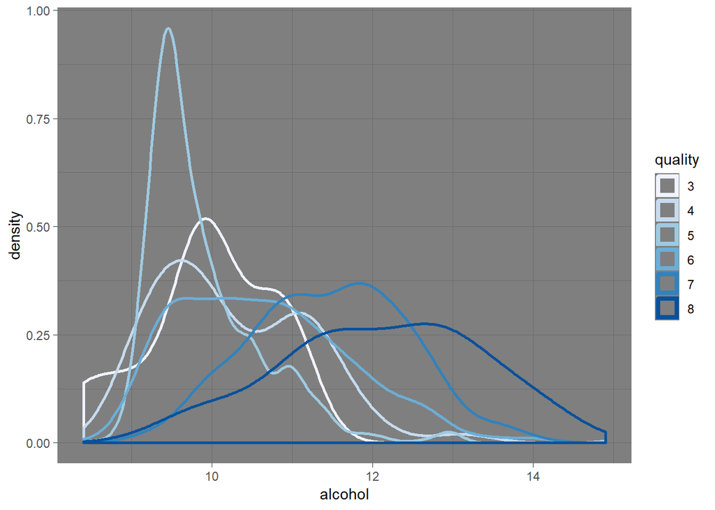

Regarding alcohol, it is evident that wines with lower quality score tend to be skewed to the right, or they are more likely to have less alcohol percentage, 12 % or below. For wines with more than 12 % of alcohol, it is more common to receive a better quality score like 7 or 8.

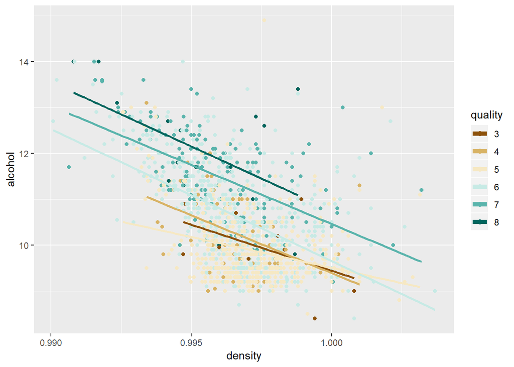

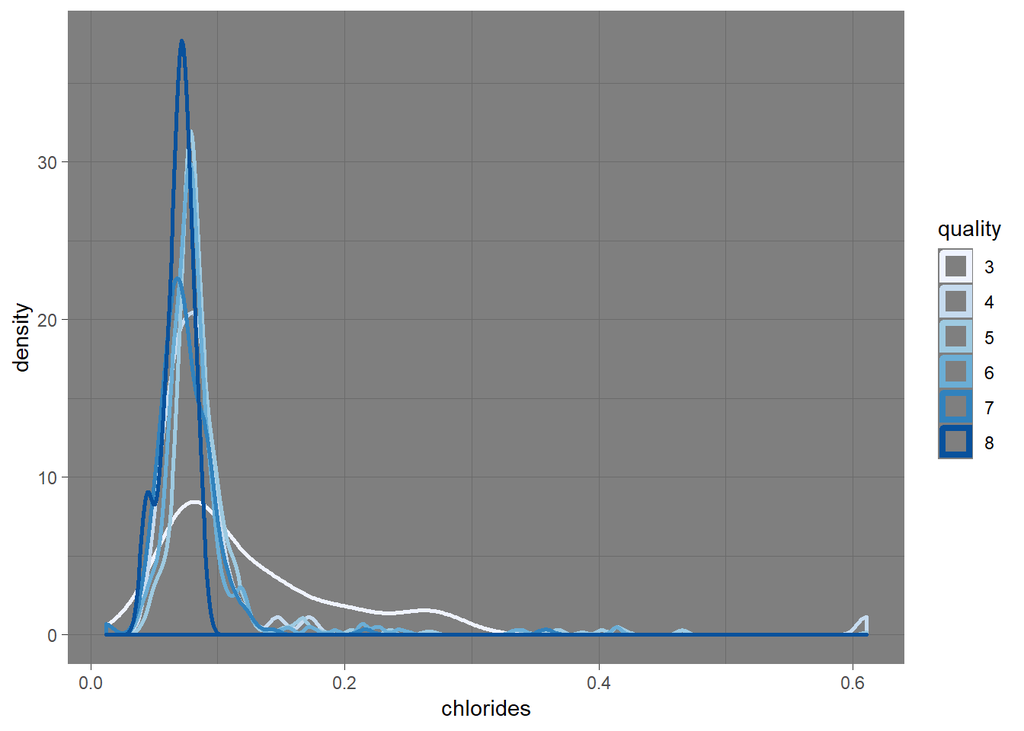

Most wines, regardless of quality score, have a chlorides amount of below 0.2. However, it appears as chlorides amount increases beyond 0.2, a low quality score of 3 is also much more common.